# Week 5: Data Wrangling

BIOSTAT620: Introduction to Health Data Science

Dylan Cable

## Today’s goals

We will learn about how to manipulate data, and in particular,

- Transforming data
- Selecting variables.
- Filtering data.
- Creating variables.
- Summarize data.

Throughout the session we will see examples using:

- [**data.table**](https://cran.r-project.org/package=data.table) in R,
- [**dtplyr**](https://cran.r-project.org/package=dplyr) in R, and
- [**pydatatable**](https://github.com/h2oai/datatable)

All with a fertility dataset and the [MET](https://github.com/dmcable/BIOSTAT620W26/tree/main/data/met) dataset.

## Disclaimer

There’s a lot of information in these slides! While `tidyverse`, the `data.table` package and Python all have a lot of useful functionality, we recommend sticking to the base R and `tidyverse` tools presented here. Slides covering material outside this scope will be marked with an asterisk (`*`); you should be cautious about using code from those slides!

## Tidying data

- We will work with a *wide format dataset* as an example:

```r
library(tidyverse)
library(dslabs)
library(R.utils)
path <- system.file("extdata", package = "dslabs")
filename <- file.path(path, "fertility-two-countries-example.csv")
wide_data <- read_csv(filename)
select(wide_data, 1:10)
```

```
# A tibble: 2 × 10
  country     `1960` `1961` `1962` `1963` `1964` `1965` `1966` `1967` `1968`
  <chr>        <dbl>  <dbl>  <dbl>  <dbl>  <dbl>  <dbl>  <dbl>  <dbl>  <dbl>
1 Germany       2.41   2.44   2.47   2.49   2.49   2.48   2.44   2.37   2.28
2 South Korea   6.16   5.99   5.79   5.57   5.36   5.16   4.99   4.85   4.73
```

## `pivot_longer`

- One of the most used functions in **tidyr** is `pivot_longer`.
- The first argument is a data frame, the one that will be converted.
- We want to reshape rows represents a fertility observation.
- We need three columns to store the year, country, and the observed value.

## `pivot_longer`

- In its current form, data from different years are in different columns with the year values stored in the column names.
- The `names_to` and `values_to` argument tell `pivot_longer` the column names we want to assign to the columns containing the current column names and observations, respectively.
- The default names are `name` and `value`, in our case a better choice is `year` and `fertility`.

## `pivot_longer`

- Through `cols`, the second argument, we specify the columns containing observed values; these are the columns that will be *pivoted*.
- The default is to pivot all columns so, in most cases, we have to specify the columns. In our example we want columns `1960`, `1961` up to `2015`.

## `pivot_longer`

The code to pivot the fertility data therefore looks like this:

```r
new_tidy_data <- wide_data |>
  pivot_longer(`1960`:`2015`, names_to = "year", values_to = "fertility")
head(new_tidy_data)
```

```
# A tibble: 6 × 3
  country year  fertility
  <chr>   <chr>     <dbl>
1 Germany 1960       2.41
2 Germany 1961       2.44
3 Germany 1962       2.47
4 Germany 1963       2.49
5 Germany 1964       2.49
6 Germany 1965       2.48
```

- Data have been converted to tidy format with columns `year` and `fertility`.

## `pivot_longer`

- A quicker way to write this code is to specify which column will **not** include in the pivot:

```r
new_tidy_data <- wide_data |>
  pivot_longer(-country, names_to = "year", values_to = "fertility")
```

## `pivot_longer`

- Now that the data is tidy, we can use it with other *tidyverse* functions, such **ggplot2**:

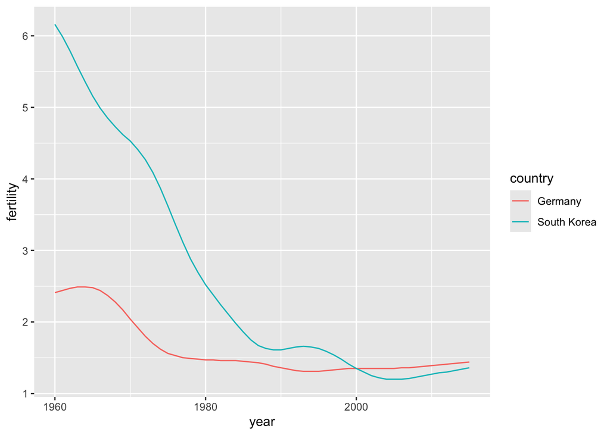

```r
new_tidy_data |>
  mutate(year = as.numeric(year)) |>
  ggplot(aes(year, fertility, color = country)) +
  geom_line()
```

## `pivot_wider`

- It is sometimes useful for data wrangling purposes to convert tidy data into wide data.
- We often use this as an intermediate step in tidying up data.
- The `pivot_wider` function is basically the inverse of `pivot_longer`.

## `pivot_wider`

- The first argument is for the data, but since we are using the pipe, we don’t show it.
- The `names_from` argument tells `pivot_wider` which variable will be used as the column names.
- The `values_from` argument specifies which variable to use to fill out the cells.

## `pivot_wider`

Here is some example code

```r
new_wide_data <- new_tidy_data |>
  pivot_wider(names_from = year, values_from = fertility)
select(new_wide_data, country, `1960`:`1967`)
```

```
# A tibble: 2 × 9
  country     `1960` `1961` `1962` `1963` `1964` `1965` `1966` `1967`
  <chr>        <dbl>  <dbl>  <dbl>  <dbl>  <dbl>  <dbl>  <dbl>  <dbl>
1 Germany       2.41   2.44   2.47   2.49   2.49   2.48   2.44   2.37
2 South Korea   6.16   5.99   5.79   5.57   5.36   5.16   4.99   4.85
```

## Example

We now demonstrate with a more complex example in which we have to use both `pivot_longer` and `pivot_wider` to tidy the data.

```r
path <- system.file("extdata", package = "dslabs")

filename <- "life-expectancy-and-fertility-two-countries-example.csv"
filename <-  file.path(path, filename)

raw_dat <- read_csv(filename)
select(raw_dat, 1:5)
```

```
# A tibble: 2 × 5
  country     `1960_fertility` `1960_life_expectancy` `1961_fertility`
  <chr>                  <dbl>                  <dbl>            <dbl>
1 Germany                 2.41                   69.3             2.44
2 South Korea             6.16                   53.0             5.99
# ℹ 1 more variable: `1961_life_expectancy` <dbl>
```

## Example

- Note that the data is in wide format.
- Also that this table includes values for two variables, fertility and life expectancy, with the column name encoding which column represents which variable.
- Encoding information in the column names is not recommended but, unfortunately, it is quite common.

## Example

- We start with the `pivot_longer` function, but we should no longer use the column name `year` for the new column since it also contains the variable type.
- We will call it `name`, the default, for now:

```r
raw_dat |> pivot_longer(-country) |> head()
```

```
# A tibble: 6 × 3
  country name                 value
  <chr>   <chr>                <dbl>
1 Germany 1960_fertility        2.41
2 Germany 1960_life_expectancy 69.3
3 Germany 1961_fertility        2.44
4 Germany 1961_life_expectancy 69.8
5 Germany 1962_fertility        2.47
6 Germany 1962_life_expectancy 70.0
```

## Example

- The result is not exactly what we refer to as tidy since each observation is associated with two, not one, rows.
- We want to have the values from the two variables, fertility and life expectancy, in two separate columns.
- The first challenge to achieve this is to separate the `name` column into the year and the variable type.

## Example

- Encoding multiple variables in a column name is such a common problem that the **tidyr** package includes function to separate these columns into two or more:

```r
raw_dat |>
  pivot_longer(-country) |>
  separate_wider_delim(name, delim = "_",  names = c("year", "name"),
                       too_many = "merge") |>
  head()
```

```
# A tibble: 6 × 4
  country year  name            value
  <chr>   <chr> <chr>           <dbl>
1 Germany 1960  fertility        2.41
2 Germany 1960  life_expectancy 69.3
3 Germany 1961  fertility        2.44
4 Germany 1961  life_expectancy 69.8
5 Germany 1962  fertility        2.47
6 Germany 1962  life_expectancy 70.0
```

## Example

- But we are not done yet.
- We need to create a column for each variable and change `year` to a number.
- As we learned, the `pivot_wider` function can do this.

## Example

```r
dat <- raw_dat |>
  pivot_longer(-country) |>
  separate_wider_delim(name, delim = "_",
                       names = c("year", "name"),
                       too_many = "merge") |>
  pivot_wider() |>
  mutate(year = as.integer(year))
head(dat)
```

```
# A tibble: 6 × 4
  country  year fertility life_expectancy
  <chr>   <int>     <dbl>           <dbl>
1 Germany  1960      2.41            69.3
2 Germany  1961      2.44            69.8
3 Germany  1962      2.47            70.0
4 Germany  1963      2.49            70.1
5 Germany  1964      2.49            70.7
6 Germany  1965      2.48            70.6
```

## Example

The data is now is now in tidy form and we can use with other packages:

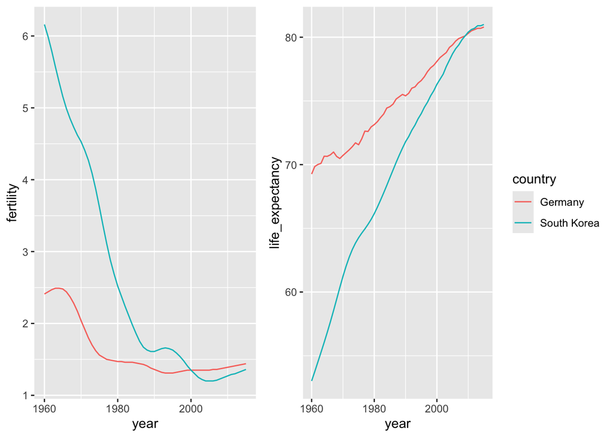

```r
p1 <- dat |> ggplot(aes(year, fertility, color = country)) + geom_line(show.legend = FALSE)
p2 <- dat |> ggplot(aes(year, life_expectancy, color = country)) + geom_line()
gridExtra::grid.arrange(p1, p2, ncol = 2, widths = c(3,4))
```

## Data wrangling in R

Overall, you will find the following approaches:

- **base R**: Use only base R functions.
- **dplyr**: Using “verbs”.
- **data.table**: High-performing (ideal for large data)
- **dplyr + data.table = dtplyr**: High-performing + dplyr verbs.

Other methods involve, for example, using external tools such as [Spark](http://spark.apache.org/), [sparkly](https://cran.r-project.org/package=sparklyr).

We will be focusing on data.table because of [this](https://h2oai.github.io/db-benchmark/)

Take a look at this very neat cheat sheet [here](https://github.com/rstudio/cheatsheets/raw/main/datatable.pdf).

## Selecting variables: Load the packages

```r
library(data.table)
library(dtplyr)
library(dplyr)
library(ggplot2)
```

The `dtplyr` R package translates `dplyr` (`tidyverse`) syntax to `data.table`, so that we can still use **the dplyr verbs** while at the same time leveraging the performance of `data.table`.

## Loading the data

The data that we will be using is an already processed version of the MET dataset. We can download (and load) the data directly in our session using the following commands:

```r
# Where are we getting the data from
met_url <- "https://github.com/dmcable/BIOSTAT620W26/raw/main/data/met/met_all.gz"

# Downloading the data to a tempfile (so it is destroyed afterwards)
# you can replace this with, for example, your own data:
tmp <- tempfile(pattern = "met", fileext = ".gz")
# tmp <- "met.gz"

# We should be downloading this, ONLY IF this was not downloaded already.
# otherwise is just a waste of time.
if (!file.exists(tmp)) {
  download.file(
    url      = met_url,
    destfile = tmp,
    # method   = "libcurl", timeout = 1000 (you may need this option)
  )
}
```

Now we can load the data using the `read.csv()` or `fread()` functions.

## Read the Data

In R (base)

```r
# Reading the data
dat <- read.csv(tmp)
head(dat)
```

In R (`data.table`)

```r
# Reading the data
dat <- fread(tmp)
head(dat)
dat <- as.data.frame(dat)
```

In Python

```python
import datatable as dt
dat = dt.fread("met.gz")
dat.head(5)
```

Before we continue, let’s learn a bit more on `data.table` and `dtplyr`

## * `data.table` and `dtplyr`: Data Table’s Syntax

- As you have seen in previous lectures, in `data.table` all happens within the square brackets. Here is common way to imagine DT:

[figure not shown]

- Any time that you see **:=** in **j** that is “Assignment by reference.” Using **=** within **j** only works in some specific cases.

## * `data.table` and `dtplyr`: Data Table’s Syntax

Operations applied in **j** are evaluated *within* the data, meaning that names work as symbols, e.g.,

```r
data("USArrests")
USArrests_dt <- data.table(USArrests)
# This returns an error
USArrests[, Murder]
# This works fine
USArrests_dt[, Murder]
```

Furthermore, we can do things like this:

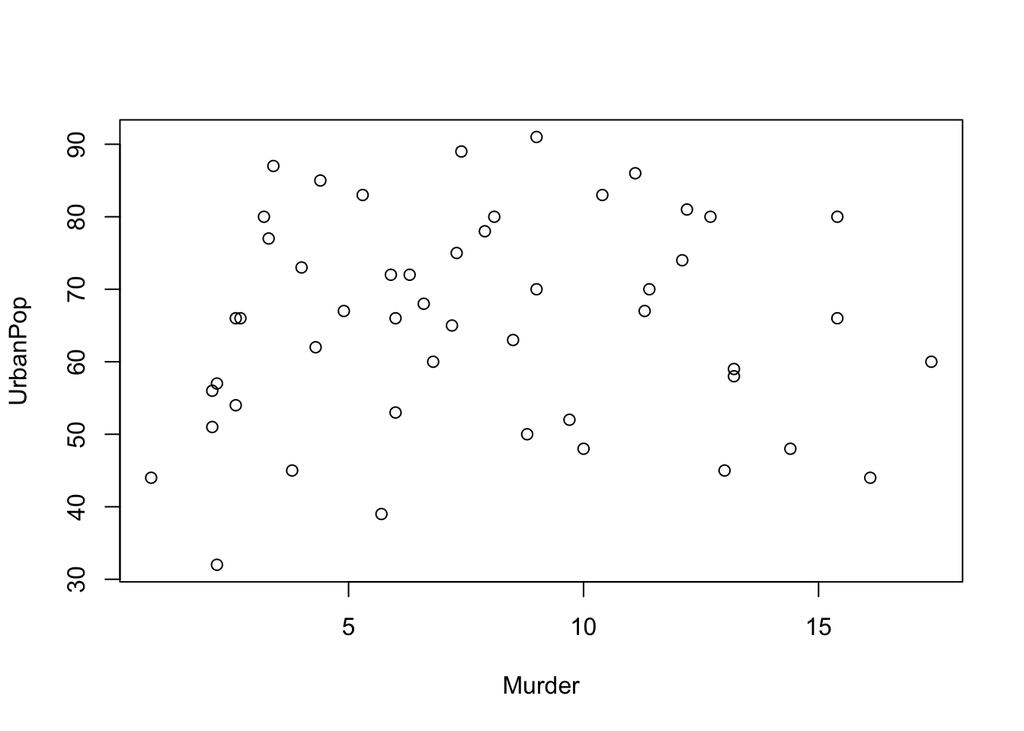

```r
USArrests_dt[, plot(Murder, UrbanPop)]
```

## * `data.table` and `dtplyr`: Lazy table

- The `dtplyr` package provides a way to translate `dplyr` verbs to `data.table` syntax.
- The key lies on the function `lazy_dt` from `dtplyr` (see `?dtplyr::lazy_dt`).
- This function creates a wrapper that “points” to a `data.table` object

## * `data.table` and `dtplyr`: Lazy table (cont.)

```r
# Creating a lazy table object
dat_ldt <- lazy_dt(dat, immutable = FALSE)

# We can use the address() function from data.table
address(dat)
address(dat_ldt$parent)
```

[figure not shown]

Question: What is the `immutable = FALSE` option used for?

## * Selecting columns

How can we select the columns `USAFID`, `lat`, and `lon`, using `data.table`:

```r
dat[, list(USAFID, lat, lon)]
# dat[, .(USAFID, lat, lon)]       # Alternative 1
# dat[, c("USAFID", "lat", "lon")] # Alternative 2
```

What happens if instead of `list()` you used `c()`?

## Selecting columns (cont. 1)

Using base R:

```r
head(
  dat[, c('USAFID', 'lat', 'lon')]
)
```

```
  USAFID  lat      lon
1 690150 34.3 -116.166
2 690150 34.3 -116.166
3 690150 34.3 -116.166
4 690150 34.3 -116.166
5 690150 34.3 -116.166
6 690150 34.3 -116.166
```

## Selecting columns (cont. 2)

Using the **dplyr::select** verb:

```r
dat |> select(USAFID, lat, lon) |> head()
```

```
  USAFID  lat      lon
1 690150 34.3 -116.166
2 690150 34.3 -116.166
3 690150 34.3 -116.166
4 690150 34.3 -116.166
5 690150 34.3 -116.166
6 690150 34.3 -116.166
```

## * Selecting columns (cont. 3)

In the case of `pydatatable`

```python
dat[:,["USAFID", "lat", "lon"]]
```

What happens if instead of `["USAFID", "lat", "lon"]` you used `{"USAFID", "lat", "lon"}` (vector vs set)?

For the rest of the session we will be using these variables: `USAFID`, `WBAN`, `year`, `month`, `day`, `hour`, `min`, `lat`, `lon`, `elev`, `wind.sp`, `temp`, and `atm.press`.

```r
# select only the relevant variables
dat <- dat |>
  select(USAFID, WBAN, year, month, day,
         hour, min, lat, lon, elev,
         wind.sp, temp, atm.press)
```

## Data filtering: Logical conditions

- Based on logical operations, e.g. `condition 1 [and|or condition2 [and|or ...]]`
- Need to be aware of ordering and grouping of `and` and `or` operators.
- Fundamental **logical** operators:

| x | y | Negate !x | And x & y | Or x \| y | Xor xor(x, y) |
| --- | --- | --- | --- | --- | --- |
| true | true | false | true | true | false |
| false | true | true | false | true | true |
| true | false | false | false | true | true |
| false | false | true | false | false | false |

- Fundamental **relational** operators, in R: `<`, `>`, `<=`, `>=`, `==`, `!=`.

## Questions 1: How many ways can you write an XOR operator?

Write a function that takes two arguments `(x,y)` and applies the XOR operator element wise. Here you have a template:

```r
myxor <- function(x, y) {
  res <- logical(length(x))
  for (i in 1:length(x)) {
    res[i] <- # do something with x[i] and y[i]
  }
  return(res)
}
```

Or if vectorized (which would be better)

```r
myxor <- function(x, y) {
  # INSERT YOUR CODE HERE
}
```

Hint 1: Remember that negating `(x & y)` equals `(!x | !y)`.

Hint 2: Logical operators are a distributive, meaning `a * (b + c) = (a * b) + (a * c)`, where `*` and `+` are `&` or `|`.

In R

```r
myxor1 <- function(x,y) {(x & !y) | (!x & y)}
myxor2 <- function(x,y) {!((!x | y) & (x | !y))}
myxor3 <- function(x,y) {(x | y) & (!x | !y)}
myxor4 <- function(x,y) {!((!x & !y) | (x & y))}
cbind(
  ifelse(xor(test[,1], test[,2]), "true", "false"),
  ifelse(myxor1(test[,1], test[,2]), "true", "false"),
  ifelse(myxor2(test[,1], test[,2]), "true", "false"),
  ifelse(myxor3(test[,1], test[,2]), "true", "false"),
  ifelse(myxor4(test[,1], test[,2]), "true", "false")
)
```

```
     [,1]    [,2]    [,3]    [,4]    [,5]
[1,] "false" "false" "false" "false" "false"
[2,] "true"  "true"  "true"  "true"  "true"
[3,] "true"  "true"  "true"  "true"  "true"
[4,] "false" "false" "false" "false" "false"
```

## * Or in python

```python
# Loading the libraries
import numpy as np
import pandas as pa

# Defining the data
x = [True, True, False, False]
y = [False, True, True, False]
ans = {
    'x'   : x,
    'y'   : y,
    'and' : np.logical_and(x, y),
    'or'  : np.logical_or(x, y),
    'xor' : np.logical_xor(x, y)
    }
pa.DataFrame(ans)
```

## * Or in python (bis)

```python
def myxor(x,y):
    return np.logical_or(
        np.logical_and(x, np.logical_not(y)),
        np.logical_and(np.logical_not(x), y)
    )

ans['myxor'] = myxor(x,y)
pa.DataFrame(ans)
```

We will now see applications using the `met` dataset

## Filtering (subsetting) the data

Say we need to select records according to some criteria. For example:

- First day of the month, and
- Above latitude 40, and
- Elevation outside the range 500 and 1,000.

The logical expressions would be

- `(day == 1)`
- `(lat > 40)`
- `((elev < 500) | (elev > 1000))`

Respectively.

## * data.table

In R with `data.table`:

```r
dat[(day == 1) & (lat > 40) & ((elev < 500) | (elev > 1000))] |>
  nrow()
```

In base R:

```r
tmp <- dat[dat$day == 1 &
             dat$lat > 40 &
             (dat$elev < 500 | dat$elev > 1000), ]
head(tmp)
```

```
     USAFID  WBAN year month day hour min    lat     lon elev wind.sp temp
3009 720113 54829 2019     8   1    0  15 42.543 -83.178  222     1.5 25.0
3010 720113 54829 2019     8   1    0  39 42.543 -83.178  222     2.6 24.4
3011 720113 54829 2019     8   1    0  57 42.543 -83.178  222     4.1 24.0
3012 720113 54829 2019     8   1    1  15 42.543 -83.178  222     4.1 23.5
3013 720113 54829 2019     8   1    1  16 42.543 -83.178  222     3.6 23.5
3014 720113 54829 2019     8   1    1  35 42.543 -83.178  222     3.1 23.0
     atm.press
3009        NA
3010        NA
3011        NA
3012        NA
3013        NA
3014        NA
```

```r
nrow(tmp)
```

```
[1] 27623
```

In R with **dplyr::filter()**:

```r
dat |>
  filter(day == 1, lat > 40, (elev < 500) | (elev > 1000)) |>
  head()
```

```
  USAFID  WBAN year month day hour min    lat     lon elev wind.sp temp
1 720113 54829 2019     8   1    0  15 42.543 -83.178  222     1.5 25.0
2 720113 54829 2019     8   1    0  39 42.543 -83.178  222     2.6 24.4
3 720113 54829 2019     8   1    0  57 42.543 -83.178  222     4.1 24.0
4 720113 54829 2019     8   1    1  15 42.543 -83.178  222     4.1 23.5
5 720113 54829 2019     8   1    1  16 42.543 -83.178  222     3.6 23.5
6 720113 54829 2019     8   1    1  35 42.543 -83.178  222     3.1 23.0
  atm.press
1        NA
2        NA
3        NA
4        NA
5        NA
6        NA
```

In Python

```python
import datatable as dt
dat = dt.fread("met.gz")
```

```python
dat[(dt.f.day == 1) & (dt.f.lat > 40) & ((dt.f.elev < 500) | (dt.f.elev > 1000)), :].nrows
# dat[dt.f.day == 1,:][dt.f.lat > 40,:][(dt.f.elev < 500) | (dt.f.elev > 1000),:].nrows
```

In the case of pydatatable we use `dt.f.` to refer to a column. `df.` is what we use to refer to datatable’s [namespace](https://en.wikipedia.org/wiki/Namespace).

The `f.` is a [symbol](https://datatable.readthedocs.io/en/latest/manual/f-expressions.html) that allows accessing column names in a datatable’s `Frame`.

## Questions 2

1. How many records have a temperature within 18 and 25?
2. Some records have missing values. Count how many records have `temp` as `NA`.
3. Following the previous question, plot a sample of 1,000 pairs of `(lat, lon)` coordinates for (a) the stations with `temp` as `NA` and (b) those with data.

## Solutions

```r
# Question 1
nrow(dat[dat$temp < 25 & dat$temp > 18, ])
# dat[temp %between% c(18, 25), .N]
# dat |> filter(between(temp, 18, 25)) |> nrow()

# Question 2
nrow(dat[is.na(dat$temp), ])
# more succinct: sum(is.na(dat$temp))
```

```
[1] 968136
[1] 60089
```

## Solutions (cont.)

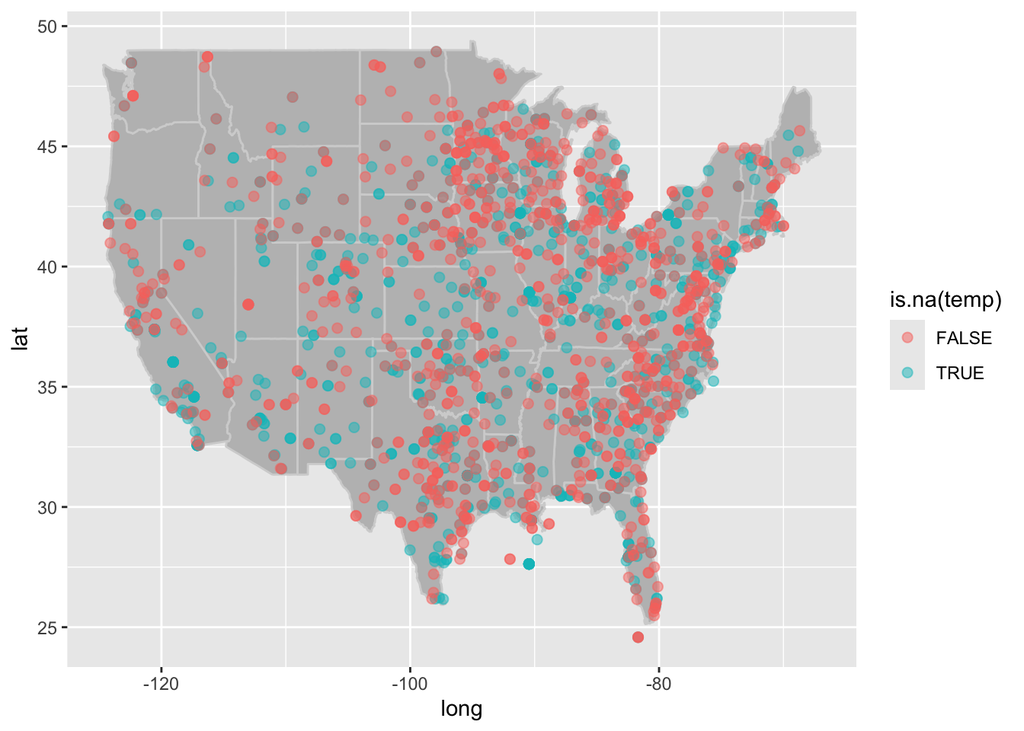

```r
# Question 3
# Drawing a sample
set.seed(123)
idx1 <- sample(which(is.na(dat$temp)), 1000)
idx2 <- sample(which(!is.na(dat$temp)), 1000)

# Visualizing the data
# make a map of the US, as we did last class
ggplot(map_data("state"), aes(x = long, y = lat)) +
  geom_map(aes(map_id = region), map = map_data("state"), col = "lightgrey", fill = "gray") +
  geom_jitter(
    data    = dat[c(idx1, idx2), ],
    mapping = aes(x = lon, y = lat, col = is.na(temp)),
    inherit.aes = FALSE, alpha = .5, cex = 2
    )
```

## Creating variables: Data types

- **logical**: Bool true/false type, e.g. dead/alive, sick/healthy, good/bad, yes/no, etc.
- **strings**: string of characters (letters/symbols), e.g. names, text, etc.
- **integer**: Numeric variable with no decimal (discrete), e.g. age, days, counts, etc.
- **double**: Numeric variable with decimals (continuous), e.g. distance, expression level, time.

In C (and other languages), strings, integers, and doubles may be specified with size, e.g. integers can be of 8, 16, and 32 bits. This is relevant when managing large datasets, where saving space can be fundamental ([more info](https://en.wikipedia.org/wiki/C_data_types#Main_types)).

## Creating variables: Special data types

Most programming languages have special types which are built using basic types. A few examples:

- **time**: Could be date, date + time, or a combination of both. Usually it has a reference number defined as date 0. In R, the `Date` class has as reference 1970-01-01, in other words, “days since January 1st, 1970”.
- **categorical**: Commonly used to represent strata/levels of variables, e.g. a variable “country” could be represented as a factor, where the data is stored as numbers but has a label.
- **ordinal**: Similar to factor, but it has ordering, e.g. “satisfaction level: 5 very satisfied, …, 1 very unsatisfied”.

Other special data types could be ways to represent missings (usually described as `na` or `NA`), or special numeric types, e.g. `+-Inf` and Undefined (`NaN`).

When storing/sharing datasets, it is a good practice to do it along a dictionary describing each column data type/format.

## Questions 3: What’s the best way to represent the following

- 0, 1, 1, 0, 0, 1
- Diabetes type 1, Diabetes type 2, Diabetes type 1, Diabetes type 2
- on, off, off, on, on, on
- 5, 10, 1, 15, 0, 0, 1
- 1.0, 2.0, 10.0, 6.0
- high, low, medium, medium, high
- -1, 1, -1, -1, 1,
- .2, 1.5, .8, $\pi$
- $\pi$, $\exp{1}$, $\pi$, $\pi$

## Variable creation

If we wanted to create two variables, `elev^2` and the scaled version of `wind.sp` by it’s standard error, we could do the following

```r
dat$elev2 <- dat$elev^2
dat$windsp_scaled <- dat$wind.sp / sd(dat$wind.sp, na.rm = TRUE)
```

## Variable creation (cont. 1)

With the verb **dplyr::mutate()**:

```r
dat |>
  mutate(
    elev2         = elev ^ 2,
    windsp_scaled = wind.sp / sd(wind.sp,na.rm=TRUE)
  ) |>
  head()
```

```
  USAFID  WBAN year month day hour min  lat      lon elev wind.sp temp
1 690150 93121 2019     8   1    0  56 34.3 -116.166  696     5.7 37.2
2 690150 93121 2019     8   1    1  56 34.3 -116.166  696     8.2 35.6
3 690150 93121 2019     8   1    2  56 34.3 -116.166  696     6.7 34.4
4 690150 93121 2019     8   1    3  56 34.3 -116.166  696     5.1 33.3
5 690150 93121 2019     8   1    4  56 34.3 -116.166  696     2.1 32.8
6 690150 93121 2019     8   1    5  56 34.3 -116.166  696     0.0 31.1
  atm.press  elev2 windsp_scaled
1    1009.9 484416      2.654379
2    1010.3 484416      3.818580
3    1010.6 484416      3.120059
4    1011.6 484416      2.374970
5    1012.7 484416      0.977929
6    1012.7 484416      0.000000
```

## Variable creation (cont. 2)

Imagine that we needed to scale multiple variables by their SD and didn’t want to copy-paste this code several times. Here’s how we could do it automatically for a given list of variable names:

```r
# Listing the names
names  <- c("wind.sp", "temp", "atm.press")

for(var in names){
  dat[,paste0(var,'_scaled')] <- dat[,var] / sd(dat[,var], na.rm = TRUE)
}
```

Why can’t we use `dat$var` inside the loop?

## * Or with data.table

```r
in_names  <- c("wind.sp", "temp", "atm.press")
out_names <- paste0(in_names, "_scaled")
dat[,
    c(out_names) := lapply(.SD, function(x) x/sd(x, na.rm = TRUE)),
    .SDcols = in_names
    ]

# Looking at the first 6
head(dat[, .SD, .SDcols = out_names], n = 4)
```

Key things to notice here: **c(out_names)**, **.SD**, and **.SDCols**.

## Variable creation (cont. 3)

In the case of dplyr, we could use the following

```r
names  <- c("wind.sp", "temp", "atm.press")
dat |>
  mutate(
    across(
      all_of(names),
      function(x) x/sd(x, na.rm = TRUE),
      .names = "{col}_scaled2"
      )
  ) |>
  # Just to print the last columns
  select(ends_with("_scaled2")) |>
  head(n = 4)
```

```
  wind.sp_scaled2 temp_scaled2 atm.press_scaled2
1        2.654379     6.139348          248.7889
2        3.818580     5.875290          248.8874
3        3.120059     5.677247          248.9613
4        2.374970     5.495707          249.2077
```

## Complex variable creation

Don’t forget about loops! `for` loops and `sapply` may be slow on a dataset of this size, but they can be quite handy for creating variables that rely on complicated relationships between variables. Consider this a “brute force” approach. Vectorized methods will *always* be faster, but these can be easier to conceptualize and, in rare cases, may be the only option.

Consider the problem creating a weird variable: `wind.temp`. This will take on 4 possible values, based on the temperature and wind speed: cool & still, cool & windy, warm & still, or warm & windy. We will split each variable based on their median value. Note that this code is too slow to actually run on this large dataset.

## Complex variable creation (cont 1)

Here’s how we would do that with the `sapply` function (and a custom, unnamed function):

```r
# create the new variable one entry at a time
wind.temp <- sapply(1:nrow(dat), function(i){
  if(is.na(dat$temp[i]) | is.na(dat$wind.sp[i])){
    return(NA)
  }
  if(dat$temp[i] <= median(dat$temp, na.rm=TRUE)){
    if(dat$wind.sp[i] <= median(dat$wind.sp, na.rm=TRUE)){
      return('cool & still')
    }else{
      return('cool & windy')
    }
  }else{
    if(dat$wind.sp[i] <= median(dat$wind.sp, na.rm=TRUE)){
      return('warm & still')
    }else{
      return('warm & windy')
    }
  }
})
```

Check: what would we need to change to add this variable to our dataset?

## Complex variable creation (cont 2)

Here’s the code for doing that with a `for` loop:

```r
# initialize a variable of all missing values
wind.temp <- rep(NA, nrow(dat))
# fill in the values one at a time
for(i in 1:nrow(dat)){
  if(is.na(dat$temp[i]) | is.na(dat$wind.sp[i])){
    return(NA)
  }else{
    if(dat$temp[i] <= median(dat$temp, na.rm=TRUE)){
      if(dat$wind.sp[i] <= median(dat$wind.sp, na.rm=TRUE)){
        wind.temp[i] <- 'cool & still'
      }else{
        wind.temp[i] <- 'cool & windy'
      }
    }else{
      if(dat$wind.sp[i] <= median(dat$wind.sp, na.rm=TRUE)){
        wind.temp[i] <- 'warm & still'
      }else{
        wind.temp[i] <- 'warm & windy'
      }
    }
  }
}
```

Check: why do we need to include `na.rm=TRUE` when calculating the medians?

## Complex variable creation (cont 3)

Here’s a simple vectorized approach that will actually run on a large dataset. This works for our current case, but it’s still a brute force approach, because we had to specifically assign every possible value of our new variable. You can imagine that as the number of possible values increases, this code will get increasingly cumbersome.

```r
# initialize a variable of all missing values
wind.temp <- rep(NA, nrow(dat))
# assign every possible value by subsetting
wind.temp[dat$temp <= median(dat$temp, na.rm=TRUE) &
            dat$wind.sp <= median(dat$wind.sp, na.rm=TRUE)] <- 'cool & still'
wind.temp[dat$temp <= median(dat$temp, na.rm=TRUE) &
            dat$wind.sp > median(dat$wind.sp, na.rm=TRUE)] <- 'cool & windy'
wind.temp[dat$temp > median(dat$temp, na.rm=TRUE) &
            dat$wind.sp <= median(dat$wind.sp, na.rm=TRUE)] <- 'warm & still'
wind.temp[dat$temp > median(dat$temp, na.rm=TRUE) &
            dat$wind.sp > median(dat$wind.sp, na.rm=TRUE)] <- 'warm & windy'

head(wind.temp)
```

```
[1] "warm & windy" "warm & windy" "warm & windy" "warm & windy" "warm & still"
[6] "warm & still"
```

## Merging data

- While building the MET dataset, we dropped the State data.
- We can use the original Stations dataset and *merge* it to the MET dataset.
- But we cannot do it right away. We need to process the data somewhat first.

## Merging data (cont. 1)

```r
stations <- fread("https://noaa-isd-pds.s3.amazonaws.com/isd-history.csv")
stations <- as.data.frame(stations)
stations$USAF <- as.integer(stations$USAF)

# Dealing with NAs and 999999
stations$USAF[stations$USAF == 999999] <- NA
stations$CTRY[stations$CTRY == ""] <- NA
stations$STATE[stations$STATE == ""] <- NA

# Selecting the three relevant columns, and keep unique records
stations <- unique(stations[, c('USAF', 'CTRY', 'STATE')])

# Dropping NAs
stations <- stations[!is.na(stations$USAF), ]

head(stations, n = 4)
```

```
  USAF CTRY STATE
1 7018 <NA>  <NA>
2 7026   AF  <NA>
3 7070   AF  <NA>
4 8260 <NA>  <NA>
```

## Merging data (cont. 2)

```r
merge(
  # Data
  x     = dat,
  y     = stations,
  # List of variables to match
  by.x  = "USAFID",
  by.y  = "USAF",
  # Which obs to keep?
  all.x = TRUE,
  all.y = FALSE
  ) |> nrow()
```

```
[1] 2385443
```

This is more rows! The original dataset, `dat`, has 2377343. This means that the `stations` dataset has duplicated IDs. We can fix this:

```r
stations <- stations[!duplicated(stations$USAF), ]
```

## Merging data (cont. 3)

We now can use the function `merge()` to add the extra data

```r
dat <- merge(
  # Data
  x     = dat,
  y     = stations,
  # List of variables to match
  by.x  = "USAFID",
  by.y  = "USAF",
  # Which obs to keep?
  all.x = TRUE,
  all.y = FALSE
  )

head(dat[, c('USAFID', 'WBAN', 'STATE')], n = 4)
```

```
  USAFID  WBAN STATE
1 690150 93121    CA
2 690150 93121    CA
3 690150 93121    CA
4 690150 93121    CA
```

What happens when you change the options `all.x` and `all.y`?

## * Aggregating data: Adding grouped variables

- Many times we need to either impute some data, or generate variables by strata.
- If we, for example, wanted to impute missing temperature with the daily state average, we could use **by** together with the **data.table::fcoalesce()** function:

```r
dat[, temp_imp := fcoalesce(temp, mean(temp, na.rm = TRUE)),
  by = .(STATE, year, month, day)]
```

## Aggregating data: Adding grouped variables

- In the case of dplyr, we can do the following using **dplyr::group_by()** together with **dplyr::coalesce()**:

```r
dat <- dat |>
  group_by(STATE, year, month, day) |>
  mutate(
    temp_imp = coalesce(temp, mean(temp, na.rm = TRUE))
    )
```

## Aggregating data: Adding grouped variables (cont. 1)

Let’s see how it looks:

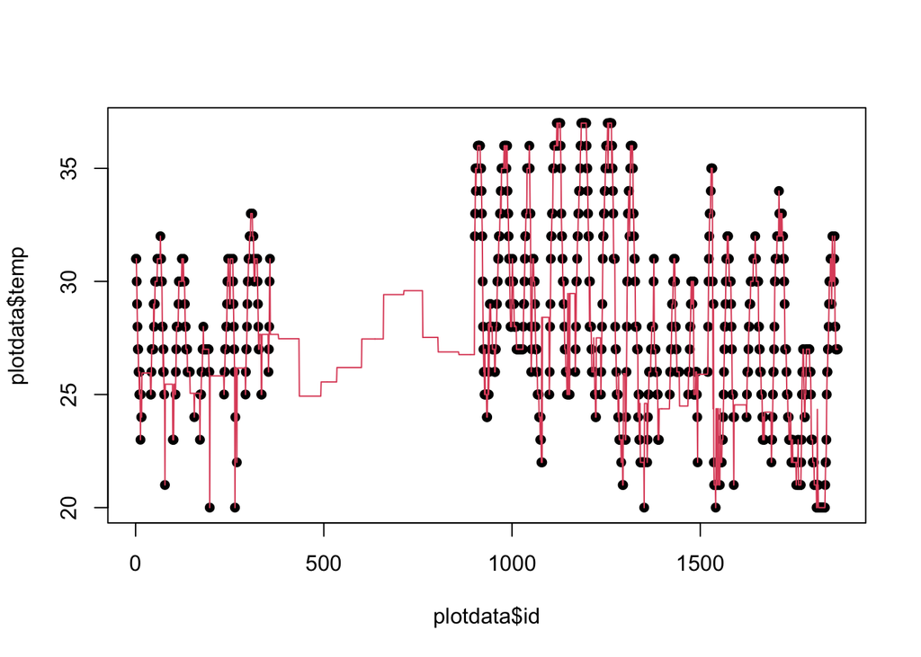

```r
# Preparing for plotting
# select single station, sort by date
plotdata <- dat[dat$USAFID == 720172, ]
plotdata <- plotdata[order(plotdata$year, plotdata$month, plotdata$day, plotdata$hour, plotdata$min), ]
# Generate an 'x' variable for time
plotdata$id <- 1:nrow(plotdata)


plot(plotdata$id, plotdata$temp, pch=16)
lines(plotdata$id, plotdata$temp_imp, col=2)
```

## Aggregating data: Adding grouped variables (cont. 2)

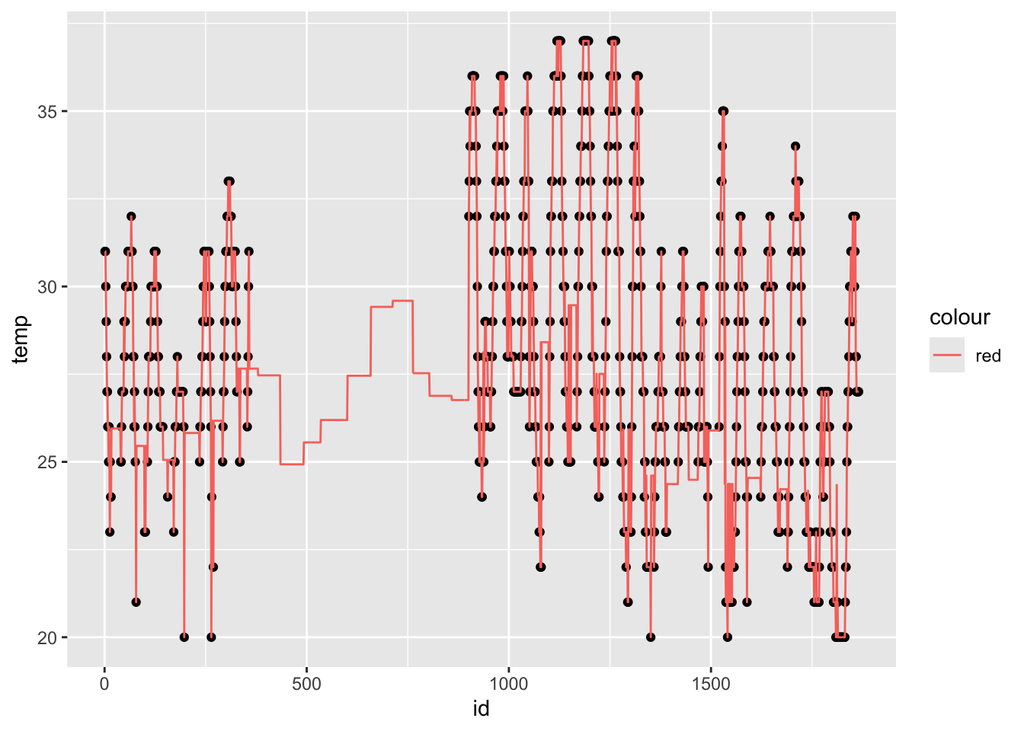

```r
plotdata |>
  ggplot(aes(x = id)) +
  geom_point(aes(y = temp)) +
  geom_line(aes(y = temp_imp, colour = 'red'))
```

## Aggregating data: Adding grouped variables (cont. 3)

Note that when you use `group_by()`, your data **stays** grouped.

```r
head(dat)
```

```
# A tibble: 6 × 21
# Groups:   STATE, year, month, day [1]
  USAFID  WBAN  year month   day  hour   min   lat   lon  elev wind.sp  temp
   <int> <int> <int> <int> <int> <int> <int> <dbl> <dbl> <int>   <dbl> <dbl>
1 690150 93121  2019     8     1     0    56  34.3 -116.   696     5.7  37.2
2 690150 93121  2019     8     1     1    56  34.3 -116.   696     8.2  35.6
3 690150 93121  2019     8     1     2    56  34.3 -116.   696     6.7  34.4
4 690150 93121  2019     8     1     3    56  34.3 -116.   696     5.1  33.3
5 690150 93121  2019     8     1     4    56  34.3 -116.   696     2.1  32.8
6 690150 93121  2019     8     1     5    56  34.3 -116.   696     0    31.1
# ℹ 9 more variables: atm.press <dbl>, elev2 <dbl>, windsp_scaled <dbl>,
#   wind.sp_scaled <dbl>, temp_scaled <dbl>, atm.press_scaled <dbl>,
#   CTRY <chr>, STATE <chr>, temp_imp <dbl>
```

This can cause headaches downstream if you don’t remember that your data is grouped.

## Aggregating data: Adding grouped variables (cont. 4)

You can undo the grouping with `dplyr::ungroup()`:

```r
dat <- ungroup(dat)
head(dat)
```

```
# A tibble: 6 × 21
  USAFID  WBAN  year month   day  hour   min   lat   lon  elev wind.sp  temp
   <int> <int> <int> <int> <int> <int> <int> <dbl> <dbl> <int>   <dbl> <dbl>
1 690150 93121  2019     8     1     0    56  34.3 -116.   696     5.7  37.2
2 690150 93121  2019     8     1     1    56  34.3 -116.   696     8.2  35.6
3 690150 93121  2019     8     1     2    56  34.3 -116.   696     6.7  34.4
4 690150 93121  2019     8     1     3    56  34.3 -116.   696     5.1  33.3
5 690150 93121  2019     8     1     4    56  34.3 -116.   696     2.1  32.8
6 690150 93121  2019     8     1     5    56  34.3 -116.   696     0    31.1
# ℹ 9 more variables: atm.press <dbl>, elev2 <dbl>, windsp_scaled <dbl>,
#   wind.sp_scaled <dbl>, temp_scaled <dbl>, atm.press_scaled <dbl>,
#   CTRY <chr>, STATE <chr>, temp_imp <dbl>
```

## * Aggregating data: Summary table

- Using `by` also allow us creating summaries of our data.
- For example, if we wanted to compute the average temperature, wind-speed, and atmospheric pressure by state, we could do the following

```r
dat[, .(
  temp_avg      = mean(temp, na.rm=TRUE),
  wind.sp_avg   = mean(wind.sp, na.rm=TRUE),
  atm.press_avg = mean(atm.press, na.rm = TRUE)
  ),
  by = STATE
  ][order(STATE)] |> head(n = 4)
```

## * Aggregating data: Summary table (cont. 1)

When dealing with too many variables, we can use the `.SD` special symbol in `data.table`:

```r
# Listing the names
in_names  <- c("wind.sp", "temp", "atm.press")
out_names <- paste0(in_names, "_avg")

dat[,
  setNames(lapply(.SD, mean, na.rm = TRUE), out_names),
  .SDcols = in_names, keyby   = STATE
  ] |> head(n = 4)
```

Notice the **keyby** option here: “Group by STATE and order by STATE”.

## Aggregating data: Summary table (cont. 2)

- Using **dplyr** verbs

```r
dat |>
  group_by(STATE) |>
  summarise(
    temp_avg      = mean(temp, na.rm=TRUE),
    wind.sp_avg   = mean(wind.sp, na.rm=TRUE),
    atm.press_avg = mean(atm.press, na.rm = TRUE)
  ) |>
  arrange(STATE) |>
  head(n = 4)
```

```
# A tibble: 4 × 4
  STATE temp_avg wind.sp_avg atm.press_avg
  <chr>    <dbl>       <dbl>         <dbl>
1 AL        26.2        1.57         1016.
2 AR        26.2        1.84         1015.
3 AZ        28.8        2.98         1011.
4 CA        22.4        2.61         1013.
```

Notice the `arrange()` function.

## * Other data.table goodies

- `shift()` Fast lead/lag for vectors and lists.
- `fifelse()` Fast if-else, similar to base R’s `ifelse()`.
- `fcoalesce()` Fast coalescing of missing values.
- `%between%` A short form of `(x < lb) & (x > up)`
- `%inrange%` A short form of `x %in% lb:up`
- `%chin%` Fast match of character vectors, equivalent to `x %in% X`, where both `x` and `X` are character vectors.
- `nafill()` Fill missing values using a constant, last observed value, or the next observed value.

## Benchmarks

- [H2O.ai](https://www.h2o.ai/)’s benchmark ([link](https://h2oai.github.io/db-benchmark/)): Designed by the lead developer of data.table [Matt Dowle](https://rdatatable.gitlab.io/data.table/)
- [RStudio’s](https://rstudio.com) benchmark ([link](https://cran.r-project.org/web/packages/vroom/vignettes/benchmarks.html)): Designed as part of the benchmarks with the vroom package.